# Loan Eligibility (Project 2)

### You can view the dataset [here](https://www.kaggle.com/datasets/taweilo/loan-approval-classification-data).

# Introducing the Data

## Dataset Info

The Set contains 14 different columns of information, ranging from different categories and data types.

[output not shown]

[output not shown]

### What are we trying to answer

The Key Question we want to answer is

- **Can a Machine Learning Model predict Predict whether a loan applicant will be approved based on financial history.**

While also looking at:

- Does having a positive or negative credit history impact the likelihood of a loan?
- Which feature or features have the most influence on whether a loan is approved?

## Installing Libraries

```python
%pip install numpy pandas matplotlib seaborn imbalanced-learn
```

[output not shown]

```python
import pandas as pd
import numpy as np
import matplotlib.pyplot as plt
import seaborn as sns
from sklearn.model_selection import train_test_split
```

## Reading and Looking into the Dataset

```python
# Reads "loan_data.csv" from local folder.
LoanDf = pd.read_csv('./loan_data.csv')
LoanDf.head(10)
```

|  | person_age | person_gender | person_education | person_income | person_emp_exp | person_home_ownership | loan_amnt | loan_intent | loan_int_rate | loan_percent_income | cb_person_cred_hist_length | credit_score | previous_loan_defaults_on_file | loan_status |
| --- | --- | --- | --- | --- | --- | --- | --- | --- | --- | --- | --- | --- | --- | --- |
| 0 | 22.0 | female | Master | 71948.0 | 0 | RENT | 35000.0 | PERSONAL | 16.02 | 0.49 | 3.0 | 561 | No | 1 |
| 1 | 21.0 | female | High School | 12282.0 | 0 | OWN | 1000.0 | EDUCATION | 11.14 | 0.08 | 2.0 | 504 | Yes | 0 |
| 2 | 25.0 | female | High School | 12438.0 | 3 | MORTGAGE | 5500.0 | MEDICAL | 12.87 | 0.44 | 3.0 | 635 | No | 1 |
| 3 | 23.0 | female | Bachelor | 79753.0 | 0 | RENT | 35000.0 | MEDICAL | 15.23 | 0.44 | 2.0 | 675 | No | 1 |
| 4 | 24.0 | male | Master | 66135.0 | 1 | RENT | 35000.0 | MEDICAL | 14.27 | 0.53 | 4.0 | 586 | No | 1 |
| 5 | 21.0 | female | High School | 12951.0 | 0 | OWN | 2500.0 | VENTURE | 7.14 | 0.19 | 2.0 | 532 | No | 1 |
| 6 | 26.0 | female | Bachelor | 93471.0 | 1 | RENT | 35000.0 | EDUCATION | 12.42 | 0.37 | 3.0 | 701 | No | 1 |
| 7 | 24.0 | female | High School | 95550.0 | 5 | RENT | 35000.0 | MEDICAL | 11.11 | 0.37 | 4.0 | 585 | No | 1 |
| 8 | 24.0 | female | Associate | 100684.0 | 3 | RENT | 35000.0 | PERSONAL | 8.90 | 0.35 | 2.0 | 544 | No | 1 |
| 9 | 21.0 | female | High School | 12739.0 | 0 | OWN | 1600.0 | VENTURE | 14.74 | 0.13 | 3.0 | 640 | No | 1 |

```python
print(LoanDf.shape)
```

```
(45000, 14)
```

#### 45,000 Entries Wow!

# Scrubbing and Cleaning the Data

Before we do any type of analysis, we need to make sure the data is good for us to use. First we want to make sure there aren't any null values or any sort of unnecessary information.

The first thing we do is drop any missing values from the dataset. This can lead to some major issues for us in the future when analyzing and can lead to inconsistencies with our model later.

```python
print(LoanDf.isnull().sum())
LoanDf.dropna(inplace=True)
LoanDf = LoanDf.drop_duplicates()
LoanDf.info()
```

```
person_age                        0
person_gender                     0
person_education                  0
person_income                     0
person_emp_exp                    0
person_home_ownership             0
loan_amnt                         0
loan_intent                       0
loan_int_rate                     0
loan_percent_income               0
cb_person_cred_hist_length        0
credit_score                      0
previous_loan_defaults_on_file    0
loan_status                       0
dtype: int64
<class 'pandas.core.frame.DataFrame'>
RangeIndex: 45000 entries, 0 to 44999
Data columns (total 14 columns):
 #   Column                          Non-Null Count  Dtype
---  ------                          --------------  -----
 0   person_age                      45000 non-null  float64
 1   person_gender                   45000 non-null  object
 2   person_education                45000 non-null  object
 3   person_income                   45000 non-null  float64
 4   person_emp_exp                  45000 non-null  int64
 5   person_home_ownership           45000 non-null  object
 6   loan_amnt                       45000 non-null  float64
 7   loan_intent                     45000 non-null  object
 8   loan_int_rate                   45000 non-null  float64
 9   loan_percent_income             45000 non-null  float64
 10  cb_person_cred_hist_length      45000 non-null  float64
 11  credit_score                    45000 non-null  int64
 12  previous_loan_defaults_on_file  45000 non-null  object
 13  loan_status                     45000 non-null  int64
dtypes: float64(6), int64(3), object(5)
memory usage: 4.8+ MB
```

## Checking how many loans were approved.

```
loan_status
0    35000
1    10000
Name: count, dtype: int64
```

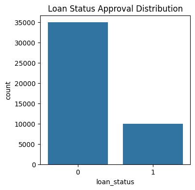

```python
print(LoanDf['loan_status'].value_counts())
plt.figure(figsize=(4,4))
sns.countplot(x=LoanDf["loan_status"])
plt.title("Loan Status Approval Distribution")
plt.show()
```

# Splitting and Training the Dataset

# Lets Talk Modeling

For modeling our data we will be taking a look at 2 different algorithms we will be using for classification.

- Logistic Regression
  - A binary classification algorithm that is able to predict the probability of certain classes based on features.
- Random Forest
  - Builds many different decision trees and combines outputs. Trained on random subsets of the data, and then the final prediction is a majority rules scenario.